# Guide for Slick Developers

Slick version 1.02

Tom Carruthers (tom@bluematterscience.com)

Adrian Hordyk (adrian@bluematterscience.com)

2021-04-28

[figure not shown]

# 1 About Slick

Slick is a decision analysis tool that presents the outcomes of potential policy options across various states of nature. The App allows for the simultaneous presentation of various performance metrics and can account for uncertainty in the states of nature. Slick is interactive and allows users to filter results live in order to explore robustness and performance.

While Slick can be applied to any decision analysis context it was specifically designed to investigate the performance of fisheries management procedures tested by management strategy evaluation (MSE).

Importantly the App is platform agnostic: results arising from any MSE framework that are formatted in a compatible Slick object can be loaded and vizualised in the App. The MSE R packages DLMtool and MSEtool are Slick-compatible and include tools to convert MSE results to the Slick format.

For more information on MSE and guidance on using the App and interpreting the results please see the [user guide](https://blue-matter.github.io/openMSE/Slick-User-Guide.html)

# 2 Purpose of this document

This document:

- Describes the format of a Slick object
- Explains how to format MSE results for use in Slick

# 3 Introduction

## 3.1 Slick Presentation of MSE Results

MSEs have four axes over which results are generally presented:

1. operating models (a state of nature or scenario for real system dynamics)
2. management procedures (MP - a management option, aka. harvest strategy)
3. performance metrics (aka. cost function, utility measure)
4. Uncertainty within an operating model (multiple simulations for each discrete state of nature)

Slick allows users to filter operating models, performance metrics and management procedures in order to explore robustness and characterize performance. Importantly, Slick is MSE-platform agnostic. Provided MSE practitioners format their results in a compatible Slick object, these can be loaded to the App.

Slick presents MSE results in 11 Figures designed to inform decision making by revealing the absolute and comparative performance of candidate management procedures .

# 4 Accessing the App

## 4.1 Online

Slick is freely available [online](https://apps.bluematterscience.com/Slick/).

## 4.2 Offline

You can also run the App locally on your computer. To do so install the [R package] (https://github.com/Blue-Matter/Slick) and use the Slick() function:

```r
library(Slick)
Slick()
```

# 5 Making custom Slick objects

It is straightforward for MSE users to present their results using Slick. To do so they must:

1. Download the Slick R package.
2. Create a blank Slick object.
3. Populate the various slots of the object with their data, text and labelling.
4. Save the Slick object and upload it to the App.

Slick objects have the following dimensions:

- deterministic performance metrics (nD)
- stochastic performance metrics (nS)
- projected performance metrics (nP)
- management options (nMO)
- simulations (nsim)
- projection years (nProjYr)
- state variables (nStateVar)
- historical years (nHistYr)

When you create a blank Slick object you must specify the ‘shape’ of the results according to these dimensions:

```r
library(Slick)
Slick()
mySLICKobj = NewSlick(nPerf=list(nD=5,nS=6,nP=7), # The number of deterministic (nD), stochastic (nS) and projected performance metrics (nP)
                      nMPs=5,      # The number of management procedures
                      nsim=10,     # The number of simulations per operating model and MP
                      nProjYr=50,  # The number of MSE projection years
                      nStateVar=2, # The number of state variables (e.g. spawning stock biomass)
                      nHistYr=55,  # The number of historical years
                      Design=as.matrix(expand.grid(1:2,1:2) # The operating model design grid
                     )
```

You can also see a final argument for the NewSlick function and that is ‘Design’. This is the design matrix for the operating models: a table with a row for each operating model and a column for each factor type (e.g. natural mortality rate, resilience etc) containing the level of each factor (this is described in further detail below).

Once you have a blank Slick object you can process your MSE results in R and add them to the blank object. Below is a guide to each slot of the object and the correct format for these.

The Slick object is of class S3 (has slots that are accessed via the $ operator). The structure of the Slick object and the format of each slot is outlined in Table 1, below.

Table 1. The structure and formatting of the Slick S3 class R object.

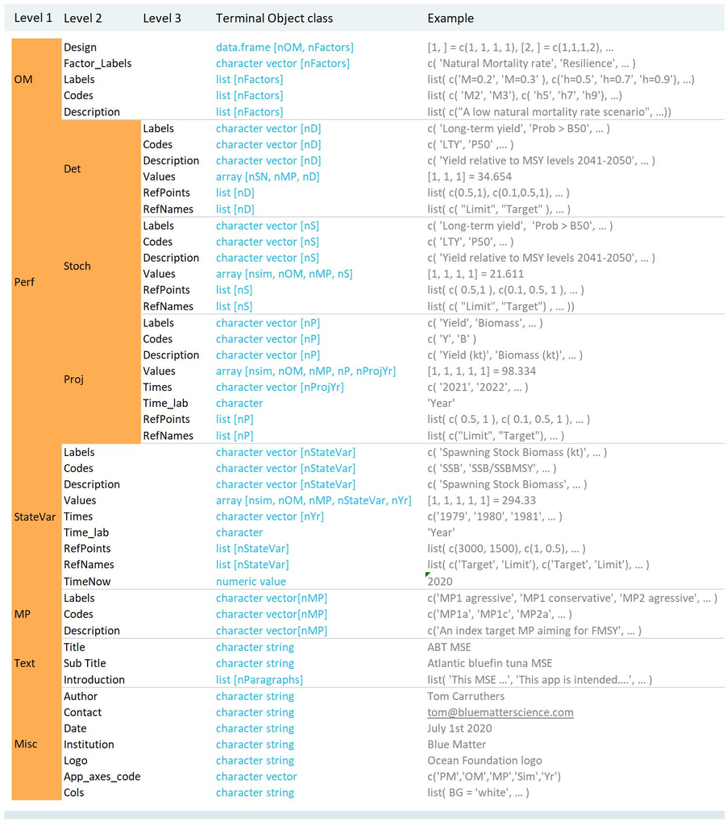

## 5.1 OM - Operating Model

All information about the various operating models is included in this slot. Operating models are often organized as orthogonal grids of various factors that represent axes of uncertainties (e.g. natural mortality, resilience, growth etc). Each of these factors can have many levels. Additionally operating models may also include reference (central uncertainties) and robustness sets. To accomodate such designs (and any other configuration), Slick uses a design grid to describe all operating models (rows) and their relevent levels of each factor (columns).

The OM slot contains five components:

- Design (a data frame representing the operating model design matrix with a row for each OM and a column for each factor)
- Factor_Labels (a character vector of the names of the factors)
- Labels (abbreviated factor-level labels for tabulation)
- Codes (further abbreviated factor-level labels for plotting purposes)
- Description (text description of each factor-level)

Here is an example of an OM slot for a Slick object that has three reference set factors (natural mortality rate, resilience, stock depletion):

```r
SLICKobj$OM
```

```
#> $Design
#>    Natural Mortality Resilience Stock Depletion Robustness
#> 1                  1          1               1          1
#> 2                  2          1               1          1
#> 3                  1          2               1          1
#> 4                  2          2               1          1
#> 5                  1          3               1          1
#> 6                  2          3               1          1
#> 7                  1          1               2          1
#> 8                  2          1               2          1
#> 9                  1          2               2          1
#> 10                 2          2               2          1
#> 11                 1          3               2          1
#> 12                 2          3               2          1
#> 13                 1          1               1          2
#> 14                 1          1               1          3
#> 15                 1          1               1          4
#> 16                 1          1               1          5
#> 17                 1          1               1          6
#>
#> $Factor_Labels
#> [1] "Natural Mortality" "Resilience"        "Stock Depletion"   "Robustness"
#>
#> $Description
#> $Description[[1]]
#> [1] "M=0.2" "M=0.3"
#>
#> $Description[[2]]
#> [1] "h=0.5" "h=0.7" "h=0.9"
#>
#> $Description[[3]]
#> [1] "Dep=0.1" "Dep=0.3"
#>
#> $Description[[4]]
#> [1] "Reference Case" "L50=0.5"        "Vmaxlen=0.1"    "Cobs=0.5"       "Perr=0.5"       "AC=0.95"
#>
#>
#> $Codes
#> $Codes[[1]]
#> [1] "M2" "M3"
```

[output cut: 8 more lines]

```
#> [1] "Ref_case" "mat_low"  "dome"     "h_Cerr"   "h_Perr"   "h_AC"
#>
#>
#> $Labels
#> $Labels[[1]]
#> [1] "M=0.2" "M=0.3"
#>
#> $Labels[[2]]
#> [1] "h=0.5" "h=0.7" "h=0.9"
#>
#> $Labels[[3]]
#> [1] "Dep=0.1" "Dep=0.3"
#>
#> $Labels[[4]]
#> [1] "Ref_Case"    "L50=0.5"     "Vmaxlen=0.1" "Cobs=0.5"    "Perr=0.5"    "AC=0.95"
```

There are 2 levels of natural mortality rate, 3 levels of resilience and 2 levels of depletion. Since these are fully orthogonal the product is 2 x 3 x 2 (12) reference operating models. Additionally there is a fourth factor for robustness / reference set operating models. Since there are 5 robustness OMs the total number of operating models (rows in the design grid) is 17.

The Labels, Codes and Description slots are all hierarchical lists that have vectors for each level name nested within factor type.

## 5.2 Perf - Performance Metrics

There are three types of performance metrics:

- Det - Deterministic (point values, one per OM, MP and deterministic metric) (e.g. mean catches in 2030 or 5th percentile of biomass in year 2050 etc.)
- Stoch - Stochastic (a value per simulation, OM, MP and stochastic metric) (e.g. average annual variability in catches 2021-2040, catch in 2040)
- Proj - Projected (a value per simulation, OM, MP, time step and projected metric) (e.g. spawning biomass relative to target levels, F relative to target levels)

```r
names(SLICKobj$Perf)
```

```
#> [1] "Det"   "Stoch" "Proj"
```

These performance metric types have varying roles in the Slick app, featuring in certain results plots only. For example, spider plots (e.g. Performance Comparison 1) are all deterministic performance metrics. Box plots (e.g. Performance Trade-offs 3) are stochastic performance metrics. Any plots that include metrics over time are plotting Projected performance metrics (e.g. Kobe plots).

The Det, Stoch and Proj slots can include varying numbers of metrics - they do not have to match. These slots can also be left empty, however without all three, some of the Slick outputs will be missing.

There are some constraints in how these metrics should be scaled for use in the App. In order to make presentation and ranking possible within the App, Deterministic and Stochastic performance metrics should take on values between 0 and 100, where 0 is poor performance and 100 is ideal performance. For example it would be necessary to take the complement of ‘probability of overfishing’ (where less is better) to derive ‘probability of not overfishing’ (where more is then better). Similarly, if variability in yields is included it may be necessary to take the additive inverse so that low variability is assigned higher values than high variability. A function is included in the Slick R package for normalizing and inverting performance metrics: PMnorm().

Projected performance metrics are used in providing Kobe-like outputs among several Slick plots. The default is to make the first projected metric SSB relative to SSBMSY (Kobe x-axis) and the second projected metric exploitation rate relative to MSY levels (F/FMSY). Other projected metrics are permissable but will not lead to conventional Kobe plot outcomes in panels labelled ‘Kobe’.

### 5.2.1 Det - Deterministic performance metrics

As in the operating model slot OM, each of the performance metric types (Det, Stoch and Proj) have Labels, Codes and Description slots that provide labels for plotting axes, further abbreviated codes for other interface features and full descriptions, respectively. These are simply character vectors:

```r
names(SLICKobj$Perf$Det)
```

```
#> [1] "Labels"      "Codes"       "Description" "Values"      "RefPoints"   "RefNames"
```

```r
SLICKobj$Perf$Det$Labels
```

```
#> [1] "Prob. AAVE < 20% (Years 1-50)"              "Prob. AAVY < 20% (Years 1-50)"              "Prob. Yield > 0.5 Ref. Yield (Years 41-50)" "Prob. SB > 0.1 SBMSY (Years 1 - 50)"        "Prob. SB > 0.5 SBMSY (Years 1 - 50)"        "Prob. SB > SBMSY (Years 1 - 50)"            "Prob. F < FMSY (Years …
```

```r
SLICKobj$Perf$Det$Codes
```

```
#> [1] "AAVE"  "AAVY"  "LTY"   "P10"   "P50"   "P100"  "PNOF"  "STY"   "Yield"
```

```r
SLICKobj$Perf$Det$Description
```

```
#> [1] "Average Annual Variability in Effort (Years 1-50)"       "Average Annual Variability in Yield (Years 1-50)"        "Average Yield relative to Reference Yield (Years 41-50)" "Spawning Biomass relative to SBMSY"                      "Spawning Biomass relative to SBMSY"                      "Sp…
```

The values of the performance metrics are stored in the Values slot that is an array with the dimensions [OM, MP, deterministic metric]. In this example there are 17 operating models, 6 management procedures and 9 deterministic performance metrics:

```r
dim(SLICKobj$Perf$Det$Values)
```

```
#> [1] 17  6  9
```

```r
range(SLICKobj$Perf$Det$Values)
```

```
#> [1]   0.000 109.393
```

Of course it is easy to do a quick check in R that you are seeing the expected values (the numbers represent the MPs):

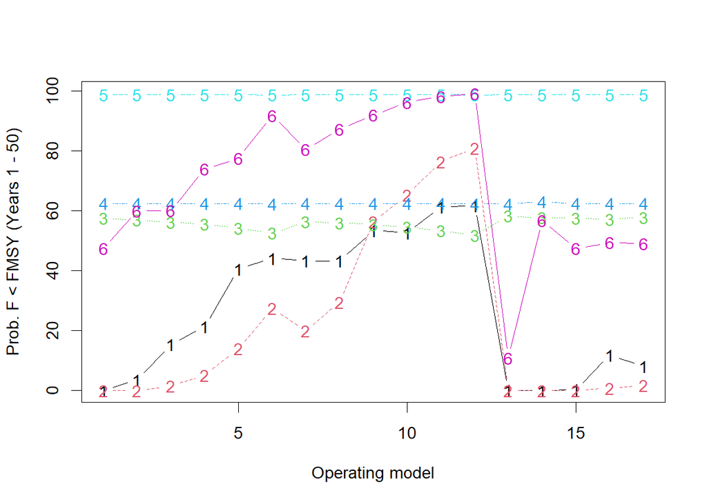

```r
matplot(SLICKobj$Perf$Det$Values[,,7],ylab=SLICKobj$Perf$Det$Labels[7],xlab="Operating model",type='b') # A quick sketch of your Det$Values data for metric #7
```

Two optional slots RefPoints and RefNames are also included that allow for the prescription of reference levels for each deterministic metric. These are lists with an entry for each metric:

```r
SLICKobj$Perf$Det$RefPoints
```

```
#> [[1]]
#> [1] NA
#>
#> [[2]]
#> [1] NA
#>
#> [[3]]
#> [1] NA
#>
#> [[4]]
#> [1] NA
#>
#> [[5]]
#> [1] NA
#>
#> [[6]]
#> [1] NA
#>
#> [[7]]
#> [1] NA
#>
#> [[8]]
#> [1] NA
#>
#> [[9]]
#> [1] NA
```

```r
SLICKobj$Perf$Det$RefNames
```

```
#> [[1]]
#> [1] NA
#>
#> [[2]]
#> [1] NA
#>
#> [[3]]
#> [1] NA
#>
#> [[4]]
#> [1] NA
#>
#> [[5]]
#> [1] NA
#>
#> [[6]]
#> [1] NA
#>
#> [[7]]
#> [1] NA
#>
#> [[8]]
#> [1] NA
#>
#> [[9]]
#> [1] NA
```

### 5.2.2 Stoch - Stochastic performance metrics

The formatting of the Stochastic performance metrics is identical to that of the deterministic metrics with the exception that the Values slot has an additional dimension for simulation (there are 48 simulations per operating model in this example).

There can be differing numbers of deterministic and stochastic performance metrics but in this example they include the same type of metric (the deteministic version was simply the mean of the stochastic values across simulations):

```r
names(SLICKobj$Perf$Stoch)
```

```
#> [1] "Labels"      "Codes"       "Description" "Values"      "RefPoints"   "RefNames"
```

```r
dim(SLICKobj$Perf$Stoch$Values)
```

```
#> [1] 48 17  6  9
```

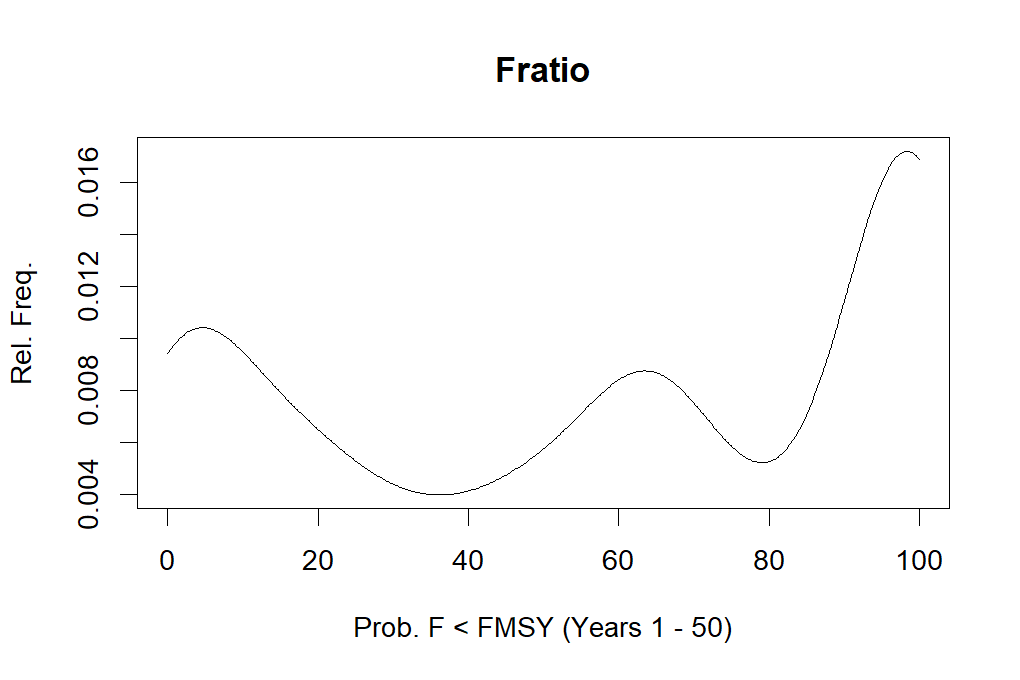

```r
plot(density(SLICKobj$Perf$Stoch$Values[,1,3,7],from=0,to=100,adj=0.5),xlab=SLICKobj$Perf$Stoch$Labels[7],main=SLICKobj$MP$Labels[3],ylab="Rel. Freq.") # Distribution of values for the third MP and 7th stochastic metric
```

### 5.2.3 Proj, Projected performance metrics

The formatting of the Projected performance metrics is identical to that of the stochastic metrics with the exception that the Values slot has additional dimensions for time (there are 50 projected years in this example) and a label for these times (Times).

```r
names(SLICKobj$Perf$Proj)
```

```
#> [1] "Labels"      "Codes"       "Description" "Values"      "Times"       "RefPoints"   "RefNames"    "Time_lab"
```

```r
SLICKobj$Perf$Proj$Times
```

```
#>  [1] 2022 2023 2024 2025 2026 2027 2028 2029 2030 2031 2032 2033 2034 2035 2036 2037 2038 2039 2040 2041 2042 2043 2044 2045 2046 2047 2048 2049 2050 2051 2052 2053 2054 2055 2056 2057 2058 2059 2060 2061 2062 2063 2064 2065 2066 2067 2068 2069 2070 2071
```

```r
dim(SLICKobj$Perf$Proj$Values)
```

```
#> [1] 48 17  6  4 50
```

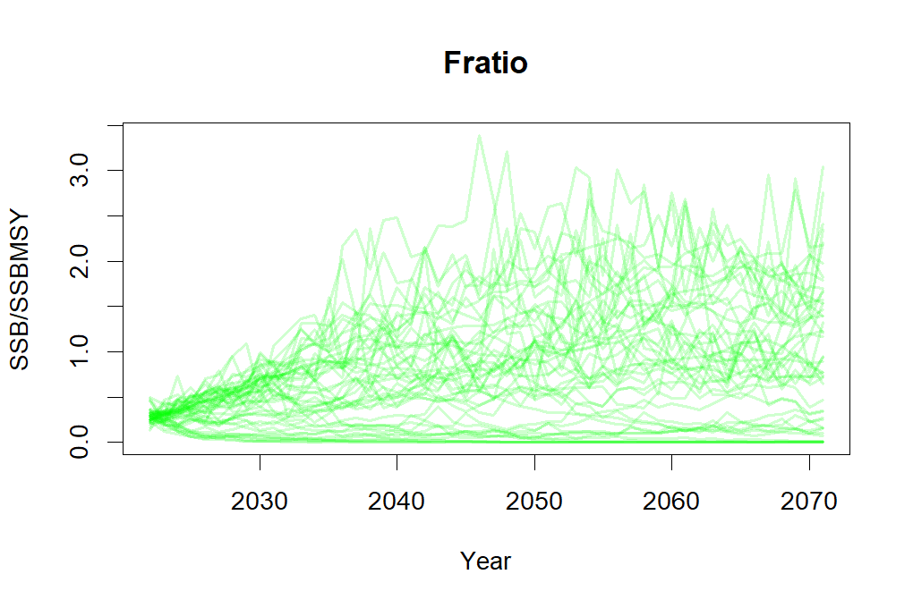

```r
matplot(SLICKobj$Perf$Proj$Times,t(SLICKobj$Perf$Proj$Values[,2,3,1,]),
        xlab=SLICKobj$Perf$Proj$Time_lab,ylab=SLICKobj$Perf$Proj$Labels[1],
        main=SLICKobj$MP$Labels[3], type="l", col="#00FF0030",lty=1,lwd=2) # Projection by simulation for the second OM, third MP and 1st stochastic metric
```

Any number of performance metrics can be included here. However, due to the default production of a Kobe-like plot (Performance Comparison 3, Performance Trade off 1 and 2), it is recommended that if they are to be reported, SSB relative to SSBMSY be placed in the first position (default x axis of the Kobe plot, greater than 1 is better) and F relative to FMSY be placed the second position (default y axis of the Kobe plot, smaller that 1 is better).

## 5.3 StateVar - State Variables

In general, MSEs start with a historical reconstruction of system dynamic from which MPs are tested under projection. State variables are quantities that have persisted in the past as well as the future and in this way provide a historical perspective on future MP performance. Examples in fisheries MSE could include spawning stock biomass, spawning numbers, recruitment etc.

The formatting of the state variables is very similar to projected performance metrics but these also include historical years and an entry ‘TimeNow’ that demarks the end of the historical reconstruction and the start of the MSE projection.

```r
names(SLICKobj$StateVar)
```

```
#> [1] "Labels"      "Codes"       "Description" "Values"      "Times"       "RefPoints"   "RefNames"    "TimeNow"     "Time_lab"
```

```r
SLICKobj$StateVar$Times
```

```
#>   [1] 1972 1973 1974 1975 1976 1977 1978 1979 1980 1981 1982 1983 1984 1985 1986 1987 1988 1989 1990 1991 1992 1993 1994 1995 1996 1997 1998 1999 2000 2001 2002 2003 2004 2005 2006 2007 2008 2009 2010 2011 2012 2013 2014 2015 2016 2017 2018 2019 2020 2021 2022 2023 2024 2025 2026 2027 2028 2029 2…
```

```r
SLICKobj$StateVar$TimeNow
```

```
#> [1] 2021
```

```r
dim(SLICKobj$StateVar$Values)
```

```
#> [1]  48  17   6   2 100
```

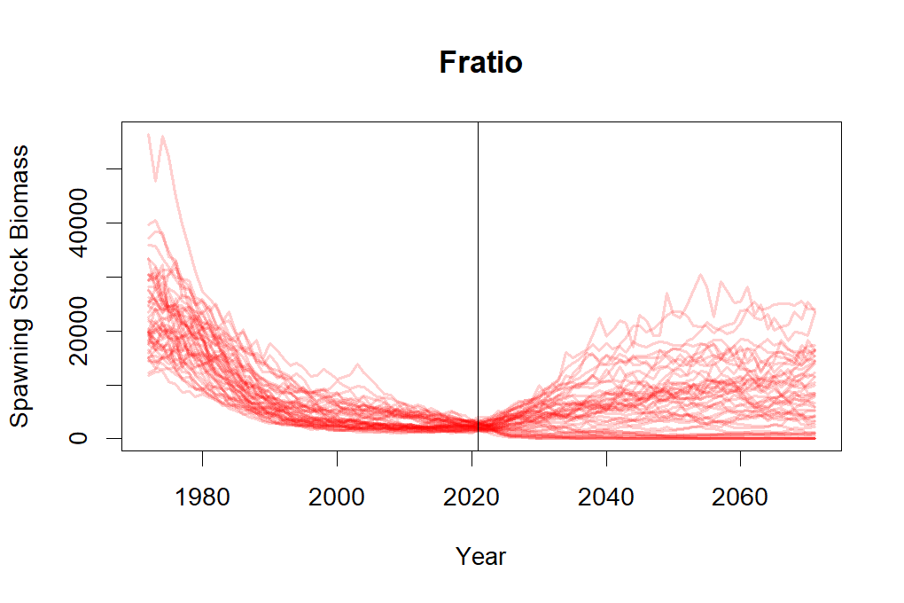

```r
matplot(SLICKobj$StateVar$Times,t(SLICKobj$StateVar$Values[,2,3,1,]),
        xlab=SLICKobj$StateVar$Time_lab,ylab=SLICKobj$StateVar$Labels[1],
        main=SLICKobj$MP$Labels[3], type="l", col="#FF000030",lty=1,lwd=2) # Projection by simulation for the second OM, third MP and 1st stochastic metric

abline(v=SLICKobj$StateVar$TimeNow)
```

## 5.4 MP - Management Procedures

The management procedures slot contains the text required to populate figures and tables in the App. It has the same Labels, Codes and Descriptions slots as the various performance metrics slots:

```r
SLICKobj$MP
```

```
#> $Labels
#> [1] "DCAC"      "AvC"       "Fratio"    "FMSYref"   "FMSYref50" "matlenlim"
#>
#> $Codes
#> [1] "DCAC"      "AvC"       "Fratio"    "FMSYref"   "FMSYref50" "matlenlim"
#>
#> $Description
#> [1] "TAC is Depletion-Corrected Average Catch (MacCall 2009)"                        "TAC is Average historical catches"                                              "TAC is a fixed ratio of FMSY/M multiplied by M, multiplied by surveyed biomass" "TAC is perfectly known FMSY fishing"             …
```

In this case the Labels and Codes are identical but in other cases it might be necessary to provide more descriptive text to the MP labels.

## 5.5 Text

The text slot allows users to provide a title and introductory text for the main page of the App.

```r
SLICKobj$Text
```

```
#> $Title
#> [1] "Slick Example"
#>
#> $Sub_title
#> [1] "Created using Make_Slick() function."
#>
#> $Introduction
#> $Introduction[[1]]
#> [1] "This is an example Slick object calculated from the test operating model of MSEtool and a set of real management procedures."
#>
#> $Introduction[[2]]
#> [1] "The primary objective of this example is to provide users with a set of MSE outputs that can be calculated quickly for\n                               demonstration purposes."
#>
#> $Introduction[[3]]
#> [1] ""
```

The Introduction slot is a list with a character string for each paragraph.

## 5.6 Misc

Finally, the Misc slot provides a place where the user can record their authorship, contact information.

```r
SLICKobj$Misc
```

```
#> $Author
#> [1] "T. Carruthers"
#>
#> $Contact
#> [1] "tom@bluematterscience.com"
#>
#> $Date
#> [1] "2021-03-24 11:17:43 PDT"
#>
#> $Institution
#> [1] "Blue Matter Science / UBC"
#>
#> $Logo
#> [1] NA
#>
#> $App_axes
#>                     PM                     SN                     MO                    Sim                   Time
#>   "Performance metric"      "Operating model" "Management Procedure"           "Simulation"                 "Year"
#>
#> $App_axes_code
#>    PM    SN    MO   Sim  Time
#>  "PM"  "OM"  "MP" "Sim"  "Yr"
#>
#> $Cols
#> $Cols$MP
#> [1] "grey"   "blue"   "orange" "purple" "red"    "brown"
#>
#> $Cols$BG
#>      main       box    spider
#>   "white" "#E4E9ED" "#E1E2E4"
#>
#> $Cols$KobeBG
#>         R     OFing        OF         G
#> "#D8775D" "#F8DC7A" "#FDBD56" "#67C18B"
#>
#> $Cols$Kobeline
#> [1] "white"
#>
#> $Cols$KobeText
#>         R     OFing        OF         G
#> "#8A003C" "#988903" "#906600" "#019046"
#>
#> $Cols$KobePoint
#>         R     OFing        OF         G
#> "#BD1018" "#EA6B1F" "#EA6B1F" "#007B3B"
#>
#> $Cols$RefPt
#>    target     limit     zeroC
#> "#03A54F" "#EE1D23" "#93B6D9"
```

App_axes is a meta-label allowing users to control how the App is presented. For example for hurricane disaster relief, the user may want to use the term ‘Hurricane path’ rather than ‘Operating model’ or ‘Evacuation plan’ instead of ‘Management procedure’.

The Cols slot allows the user to control various color schemes to customize App presentation.

# 6 Saving and uploading

To use your Slick object in the App, save it using the saveRDS function and give the file a .slick extension:

```r
saveRDS(SLICKobj,'mystock.slick')
```

This file can then be loaded from the Home page in Slick.

If your results can be made publically available, share your Slick file with the Blue Matter team and there is a chance we’ll add it to the App as an example that is available from the dropdown menu in the App. Please send your slick files to tom@bluematterscience.com.

# 7 Acknowledgements

[figure not shown]

Slick development was funded by the Ocean Foundation, with support from The Pew Charitable Trusts. Many thanks to Shana Miller, Grantly Galland and Sara Pipernos for their feedback and suggestions.

[figure not shown]

The prototype figure designs were developed by 5W Designs. Many thanks also to 5W for their helpful feedback on the Shiny App.

[figure not shown]

The Slick App, manuals and example MSE objects were coded by Blue Matter Science Ltd.

# 8 Acronyms

| Abbreviation | Description |
| --- | --- |
| MSE | Management Strategy Evaluation. Closed-loop simulation testing of management procedures. |
| MP | Management Procedure. An algorithm that accepts data as an input and provides a management recommendation as an output. |
| OM | Operating Model. Represents a scenario or state of nature for testing the performance of candidate management procedures. |
| SSB | Spawning Stock Biomass. The weight of spawning fish in the population (typically this is calculated from female mature fish) |
| MSY | Maximum Sustainable Yield. Theoretical maximum sustainable catches given asymptotic system dynamics. |
| FMSY | Theoretical fishing mortality (exploitation rate) at MSY |
| SSBMSY | Theoretical spawning stock biomass at MSY |
| BMSY | Theoretical stock biomass at MSY (often refers to spawning stock biomass) |
| SSB0 | Theoretical unfished spawning stock biomass under asymptotic unfished conditions |